# Packages

February 1, 2019

## R Packages

Packages add new capabilities to R.

Package contains: - DESCRIPTION – Name, short description, version, dependencies - R code - Man pages (help) for new code

Package may also contain: - SRC: C, Fortran, Java, … code to add functionality or to link to other tools (e.g., a database) - Data: Sample data to test functions - Vingettes: Longer narrative help that describes how to do something.

## Finding new R packages

- CRAN: Comprehensive R Archive Network
- > 13,000 packages: https://cran.r-project.org/
- Mirrors around the world https://cloud.r-project.org/
- GitHub: Many package sources are maintained there.
- Private Repositories
- Search Stack Overflow and similiar sites.

## Three Steps – Download, Install and Load

1. First, you must download the package code (either source or compiled to your computer)
2. Then the package must be *installed* in a library directory that R knows about.
- The `install.packages(name)` function will do steps 1 and 2
1. When you want to use functions from the package, you need to *load* them into the workspace.
- This can be done with `library(name)` or `require(name)`.

## Slide with R Output

```r
summary(cars)
```

```
##      speed           dist
##  Min.   : 4.0   Min.   :  2.00
##  1st Qu.:12.0   1st Qu.: 26.00
##  Median :15.0   Median : 36.00
##  Mean   :15.4   Mean   : 42.98
##  3rd Qu.:19.0   3rd Qu.: 56.00
##  Max.   :25.0   Max.   :120.00
```

## Slide with Plot

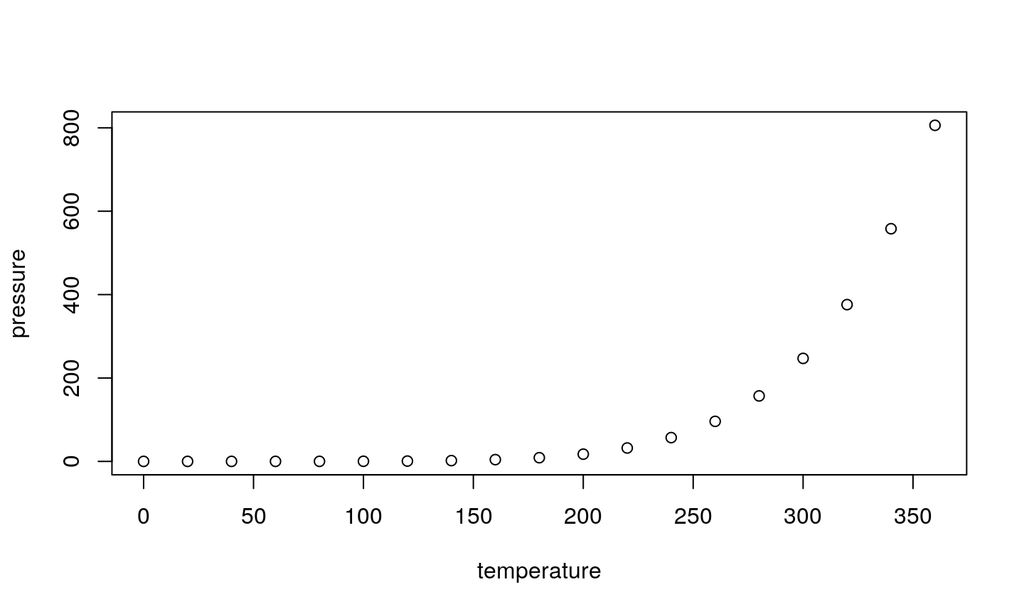